# HW 10 - Wrap up!

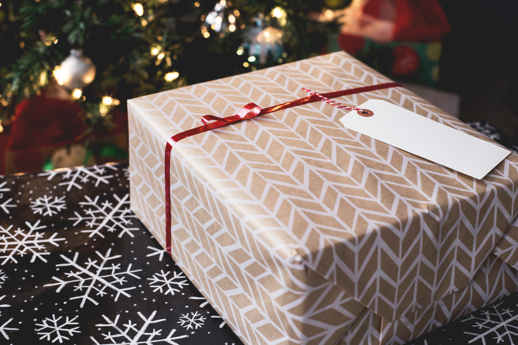

Photo by Kari Shea on Unsplash

It’s almost time to wrap up the course! In this three part assignment you get to practice what we learned this week, try something new, and get creative!

# Getting started

By now you should be familiar with instructions for getting started with a new assignment in RStudio Cloud and setting up your git configuration. If not, you can refer to one of the earlier assignments.

# Part 1 - Bootstrapping the GSS

In this part we continue our exploration of the 2016 GSS dataset from last week.

- Click [here](https://introds.org/data/gss2016.csv) to download the data. The file is called `gss2016.csv`.
- Create a `data` folder in your project – in the Files pane, click on New Folder.
- Navigate to the data folder you just created and upload the `gss2016.csv` file.
- Note that even though you made a change in your files by adding the data, `gss2016.csv` does not appear in your Git pane. This is because it’s being ignored by git.

Then, read in the data using the following:

```r
gss <- read_csv("data/gss2016.csv",
                na = c("", "Don't know",
                       "No answer", "Not applicable"),
                guess_max = 2867) %>%
  select(harass5, emailmin, emailhr, educ, born, polviews, advfront)
```

Remember that the GSS asked respondents how many hours and minutes they spend on email weekly. The responses to these questions are recorded in the `emailhr` and `emailmin` variables. For example, if the response is 2.5 hrs, this would be recorded as `emailhr = 2` and `emailmin = 30`.

Yes, this exercise is a repeat of what you did last week!

1. Create a new variable called `email` that combines these two variables to reports the number of minutes the respondents spend on email weekly.
2. Filter the data for only those who have non `NA` entries for `email`. Do not overwrite the data frame (you’ll need the full data later). Instead save the resulting data frame with a new name.
3. Describe how bootstrapping can be used to estimate the mean amount of time all Americans spend on email weekly.

# Part 2 - You gotta pick a package or two

But really, one is enough. Pick a package from the list below, and use it to do something. If you want to use a package not on this list, that’s also ok, but run it by me first by posting a question about it on Pizza (so that I can confirm it’s not one we introduced in the class so far, the goal is to work with a new package).

Remember, you install the package in the Console, not in your R Markdown document since you don’t want to keep reinstalling it every time you knit the document.

Your task is to install the package you pick. Depending on where the package comes from, how you install the package differs: - If the package is on CRAN (Comprehensive R Archive Network), you can install it with `install.packages`. - If the package is only on Github (most likely because it is still under development), you need to use the `install_github` function. See above for details.

Then, load the package. Regardless of how you installed the package you can load it with the `library` function.

Finally, do something with the package. It doesn’t have to be complicated. In fact, keep it simple. The goal is to try to read and understand the package documentation to be able to carry out a simple task.

9. Which package are you using? State the name of the package, whether it was on CRAN or GitHub, and include the code for loading it.
10. What are you doing with the package? Give me a brief narrative including code and output.

## Packages on CRAN

These packages can be installed with:

```r
install.packages("PACKAGENAME")
```

The package manuals are linked below, however developers of the packages might have additional information on the GitHub repo of the package.

- cowsay:
  - Allows printing of character strings as messages/warnings/etc. with ASCII animals, including cats, cows, frogs, chickens, ghosts, and more.
  - https://cran.r-project.org/web/packages/cowsay/vignettes/cowsay_tutorial.html
- babynames:
  - US Baby Names 1880-2015
  - https://cran.r-project.org/web/packages/babynames/babynames.pdf
- Lahman:
  - Provides the tables from the ‘Sean Lahman Baseball Database’ as a set of R data.frames. It uses the data on pitching, hitting and fielding performance and other tables from 1871 through 2015, as recorded in the 2016 version of the database.
  - https://cran.r-project.org/web/packages/Lahman/Lahman.pdf
- praise:
  - https://cran.r-project.org/web/packages/praise/praise.pdf
  - Build friendly R packages that praise their users if they have done something good, or they just need it to feel better.
- ggimage:
  - Supports image files and graphic objects to be visualized in ‘ggplot2’ graphic system.
  - https://cran.r-project.org/web/packages/ggimage/vignettes/ggimage.html
- suncalc:
  - R interface to ‘suncalc.js’ library, part of the ‘SunCalc.net’ project http://suncalc.net, for calculating sun position, sunlight phases (times for sunrise, sunset, dusk, etc.), moon position and lunar phase for the given location and time.
  - https://cran.r-project.org/web/packages/suncalc/suncalc.pdf
- ttbbeer
  - An R data package of beer statistics from U.S. Department of the Treasury, Alcohol and Tobacco Tax and Trade Bureau (TTB)
  - https://cran.r-project.org/web/packages/ttbbeer/ttbbeer.pdf

## Packages on GitHub only

These packages can be installed with:

```r
library(devtools)
install_github("USERNAME/PACKAGENAME")
```

`USERNAME` refers to the user name of the developer of the package. For example, for the first package listed below, `USERNAME` is `hadley` and `PACKAGENAME` is `emo`.

The package manuals are linked below, however developers of the packages might have additional information on the GitHub repo of the package.

- emo:
  - The goal of emo(ji) is to make it very easy to insert emoji into RMarkdown documents
  - https://github.com/hadley/emo
- gganimate:
  - Create easy animations with ggplot2
  - https://github.com/dgrtwo/gganimate
- emokid:
  - For those times when you’re having trouble expressing how you feel about your broken code.
  - https://github.com/itsrainingdata/emokid
- prenoms:
  - First names given to babies in metropolitan France between 1900 and 2015.
  - https://github.com/ThinkR-open/prenoms
- dadjoke:
  - The goal of dadjoke is to make you laugh in spite of yourself.
  - https://github.com/jhollist/dadjoke/
- cooking:
  - Chopping, peeling, frying, and cooking various ingredients, and combining them to a delicious ragout. Also includes buying them from a local supermarket.
  - https://github.com/krlmlr/cooking
- kandinsky
  - Turn any dataset into a Kandinsky paintingy
  - https://github.com/gsimchoni/kandinsky
- emoGG
  - Use emoji in your ggplot2 plots.
  - https://github.com/dill/emoGG
- lego
  - This R data package contains information about every Lego set manufactured from 1970 to 2015, a total of 6172 sets.
  - https://github.com/seankross/lego
- bingo
  - Generate Bingo cards
  - https://github.com/jennybc/bingo
- CatterPlots
  - Plots with Cats
  - https://github.com/Gibbsdavidl/CatterPlots
- BRRR
  - BRRR extends the beepr package to include a number of rap adlibs
  - https://github.com/brooke-watson/BRRR

# Part 3 - Mirror, mirror on the wall, who’s the ugliest of them all?

Here is a simple plot using the `mpg` dataset, which contains information on fuel economy of cars. We’re plotting highway miles per gallon vs. city miles per gallon, colored by whether the car is front-wheel drive, rear wheel drive, or four-wheel drive.

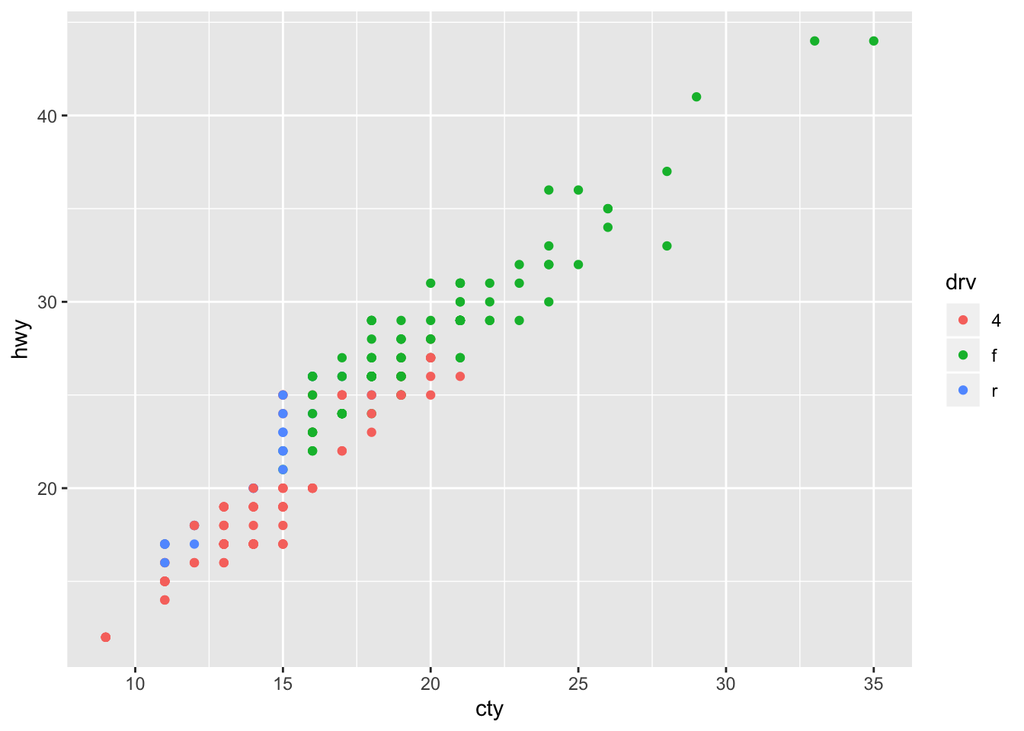

```r
ggplot(data = mpg, aes(x = cty, y = hwy, color = drv)) +
  geom_point()
```

I realize that “ugly” is subjective, so we’re mostly looking to see if you can figure out how to change the look of a plot using help files of functions you haven’t learned before.

11. Make this plot as ugly as possible by changing colors, background color, fonts, or anything else you can think of. You will probably want to play around with [theme options](https://ggplot2.tidyverse.org/reference/theme.html), but you can do more. You can also search online for other themes. fonts, etc. that you want to tweak.